# Data Wizards (Group 4) Project 1

Di Chen

Mai Castellano

Tyler Kussee

Spencer Hutchison

# Introduction

The American Community Survey offers crucial insights about our country and its citizens each year. The data from this survey plays a pivotal role in guiding the allocation of trillions of dollars in federal funding, ensuring that resources are directed where they are needed most.

With the data from the American Community Survey, the Data Wizards have come up with the following 3 questions they would like to answer:

- Does higher education mean higher income accounting for sex and age?
- Can we predict household income based on education, occupation, and race/ethnicity?
- Is there a relationship between race/ethnicity and home ownership?

In particular, we’ll be focusing on the first question to get started.

## Obtain the Data

In the case of the ACS dataset, we’ll pull it via an API. We’ve already declared our key earlier, so now we just need to pull our dataset with the variables and filtering we’d like. In this case we’ll want to pull our Age (AGEP), Education Level (SCHL), sex (SEX), and Total Person’s Income (PINCP) while filtering to the year 2022 and the State of OR.

## Scrub the data

In the data cleaning process, we began by assigning more descriptive column names to enhance clarity. Columns such as “ST”, “Serial Number”, and “housing weight” were removed as they were deemed unnecessary for our analysis, while “PersonNumber” was retained for potential future use. Subsequently, we converted instances of “bb” in the Education level column to 0, followed by transforming the Education level into numeric values. Groupings were then created based on education levels, ranging from “No Education” to “Doctoral Degree”. The column order was rearranged for better organization. As our focus is on income, individuals under the age of 14 were excluded from the dataset, aligning with Oregon’s legal working age. Variable codes were converted to their corresponding descriptions, starting with Education Level. Lastly, we identified the genders present in the dataset to facilitate further analysis. This systematic approach ensures that the data is cleaned and structured appropriately for subsequent analysis.

With the data mostly cleaned up, we can now explore the data.

## Explore the data

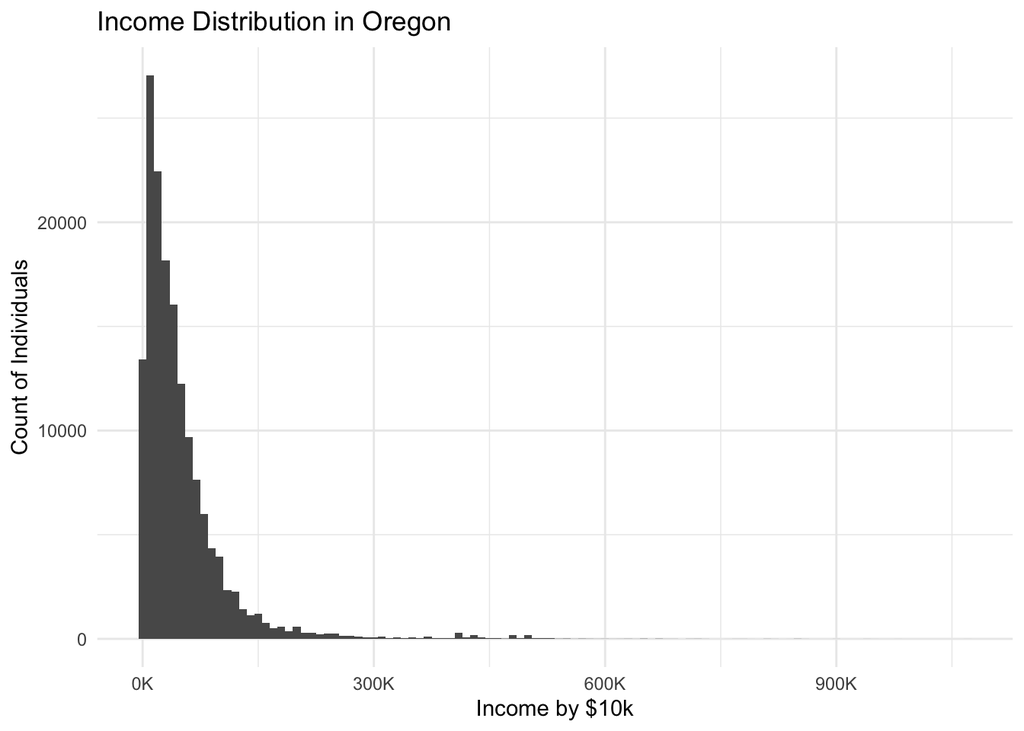

[Reference on Variables for now](https://usa.ipums.org/usa/resources/codebooks/DataDict1822.pdf)

## Model the data

We compared four regression models, each including different combinations of EducationGroup, Sex, and Age as explanatory variables. After conducting ANOVA comparisons between the full and nested models, there was compelling evidence that the last model, which included a three-way interaction term between EducationGroup, Sex, and Age along with two interaction terms between each variable, was a better fit. However, further examination of the model diagnostics revealed a violation of the linearity assumption. To address this issue, we transformed the response variable using logarithm.

## Interpret the data

To answer our question, does higher education mean higher income accounting for sex and age? Use the fitted model to compare the income across all 8 levels of education for a 50 years old males and females in Oregon.

The average income for 50-year-old males in Oregon varies significantly across different educational categories. For individuals with no schooling completed, their average income is $19,927.16, slightly lower than those with less than a high school education at $21,855.60. For those with only a high school education (without a diploma) experience a decrease in average income to $14,441.65. However, individuals with a high school diploma or GED see a notable increase in average income to $26,611.61, followed by even higher incomes for those with higher degrees.

For 50-year-old females in Oregon, a similar pattern was observed. For individuals with no schooling completed, their average income is $13,670.59, slightly increasing for those with less than a high school education to $14,888.97. Similarly observed in male, those with only a high school education (without a diploma) see a decrease in average income to $9,206.92. However, there is a significant increase in average income for females with a high school diploma or GED, reaching $17,306.20, and continuing to rise with higher educational attainment.

There is a clear relationship between educational attainment and average income for both 50-year-old males and females in Oregon. Individuals with higher levels of education tend to have higher average incomes, with notable increases observed at certain educational milestones, such as obtaining a high school diploma or GED and above.

## Appendix

```r
## An if statement for checking if a package is installed :)
#if(!require(somepackage)){
#    install.packages("somepackage")
#    library(somepackage)
#}

if (!require(tidycensus)) {
  install.packages("tidycensus")
}
if (!require(tidyverse)) {
  install.packages("tidyverse")
}
if (!require(dplyr)) {
  install.packages("dplyr")
}
if (!require(ggplot2)) {
  install.packages("ggplot2")
}

#Load libraries
library(tidycensus)
library(tidyverse)
library(dplyr)
library(ggplot2)

census_api_key("2547c95ce33b1ed0eec3aafd0fd8526a5bb9a22e")




### Obtain the Data

#Pull data set for specific variables
puma_data <- get_pums(variables = c("AGEP","SCHL","PINCP", "SEX")
                      ,state = "OR"
                      ,year = 2022)

#Rename the columns
puma_data <- puma_data %>% rename(Age = AGEP,
                                  EducationLevel = SCHL,
                                  Income = PINCP,
                                  Sex = SEX,
                                  PersonNumber = SPORDER)
head(puma_data[, 2:5])

#Remove columns that are not needed
puma_data <- puma_data %>%
  select(-ST, -SERIALNO, -WGTP, -PWGTP)
head(puma_data)

#Convert education levels
puma_data <- puma_data %>%
  mutate(
    EducationLevel = case_when(
      EducationLevel == "bb" ~ "00",
      TRUE ~ EducationLevel
    ),
    EducationLevel = as.numeric(EducationLevel)
  )

#Make sure it is numeric
class(puma_data$EducationLevel)

##Group education level
puma_data <- puma_data %>%
  mutate(
     EducationGroup = cut(EducationLevel, breaks = c(0, 2, 11, 16, 20, 21, 22, 24, Inf),
                         labels = c("No schooling completed", "Less than High School",
                                    "High School", "high school diploma or GED",
                                    "Associates Degree", "Bachelors Degree",
                                    "Masters Degree", "Doctorate Degree"),
                         right = FALSE)
  )
unique(puma_data$EducationGroup)
puma_data[1:50,]

#Rearrange the columns
puma_data <- puma_data %>%
  select(EducationGroup, EducationLevel, Income, Age, Sex, PersonNumber)
head(puma_data)

#Drop age below 14
puma_data <- puma_data %>%
  filter(Age >= 14)
head(puma_data[puma_data$Age < 14,])

#Since we're refactoring the Education levels to groups, commenting this original out.
puma_data <- puma_data %>%
  mutate(
    EducationLevel = case_when(
      EducationLevel == 0 ~ "(less than 3 years old)",
      EducationLevel == 1 ~ "No schooling completed",
      EducationLevel == 2 ~ "Nursery School / Preschool",
      EducationLevel == 3 ~ "Kindergarten",
      EducationLevel == 4 ~ "Grade 1",
      EducationLevel == 5 ~ "Grade 2",
      EducationLevel == 6 ~ "Grade 3",
      EducationLevel == 7 ~ "Grade 4",
      EducationLevel == 8 ~ "Grade 5",
      EducationLevel == 9 ~ "Grade 6",
      EducationLevel == 10 ~ "Grade 7",
      EducationLevel == 11 ~ "Grade 8",
      EducationLevel == 12 ~ "Grade 9",
      EducationLevel == 13 ~ "Grade 10",
      EducationLevel == 14 ~ "Grade 11",
      EducationLevel == 15 ~ "Grade 12 - no diploma",
      EducationLevel == 16 ~ "Regular high school diploma",
      EducationLevel == 17 ~ "GED or alternative credential",
      EducationLevel == 18 ~ "Some college, but less than 1 year",
      EducationLevel == 19 ~ "1 or more years of college credit, no degree",
      EducationLevel == 20 ~ "Associates Degree",
      EducationLevel == 21 ~ "Bachelors Degree",
      EducationLevel == 22 ~ "Masters Degree",
      EducationLevel == 23 ~ "Professional Degree beyond a Bachelors Degree",
      EducationLevel == 24 ~ "Doctorate Degree",
      TRUE ~ as.character(EducationLevel)
    )
)
puma_data[1:100,]

#Identify gender
puma_data <- puma_data %>%
  mutate(
    Sex = case_when(
      Sex == 1 ~ "Male",
      Sex == 2 ~ "Female",
      TRUE ~ as.character(Sex)
    )
)
head(puma_data)





### Explore the data
#Summarizing the ranges of numerical
summary(puma_data$Age) #Range of Age
summary(puma_data$Income) #Range of Age
summary(puma_data$EducationNumber) #Range of Education
table(puma_data$EducationLevel) #Count of each level of education

#Plot inceom distribution
ggplot(puma_data %>% filter(Income > 0), aes(Income)) +
  geom_histogram(binwidth = 10000) +
  scale_x_continuous(labels = function(x) paste0(x / 1000, "K")) +
  labs(title = "Income Distribution in Oregon"
       , x = "Income by $10k"
       , y = "Count of Individuals") +
  theme_minimal()
```

[output not shown]

```r
##[Reference on Variables for now](https://usa.ipums.org/usa/resources/codebooks/DataDict1822.pdf)




### Model the data

#Drop zero income from the data set
#Drop observation with 0 income (unemployed individuals)
puma_data <- puma_data[puma_data$Income != 0, ]
puma_data
head(puma_data)

# Does higher education mean higher income accounting for sex and age?
model_1 <- lm(Income ~ EducationGroup + Sex + Age, data = puma_data)
model_2 <- lm(Income ~ EducationGroup + Sex * Age, data = puma_data)
model_3 <- lm(Income ~ EducationGroup * Sex + Age, data = puma_data)
model_4 <- lm(Income ~ EducationGroup * Sex * Age, data = puma_data)

#Compare model 3 and 4
anova(model_3, model_4)

#The full model provides a significantly better fit.

#Compare model 2 and 4
anova(model_2, model_4)

#Model 4 is a better fit.

#Compare model 1 and 4
anova(model_1, model_4)


##Check the assumption

#Linearity and Homoscedasticity assumption
plot(fitted(model_4), residuals(model_4))
```

[output not shown]

```r
#Normality assumption
qqnorm(residuals(model_4))
qqline(residuals(model_4))
```

[output not shown]

```r
#Independence assumptions
plot(residuals(model_4))
```

[output not shown]

```r
#Fitted vs residuals plot exhibiting pattern

#Consider log transformation of the response variable:
#Logged models
model_5 <- lm(log(Income) ~ EducationGroup + Sex + Age, data = puma_data, na.action = na.exclude)
model_6 <- lm(log(Income) ~ EducationGroup + Sex * Age, data = puma_data, na.action = na.exclude)
model_7 <- lm(log(Income) ~ EducationGroup * Sex + Age, data = puma_data, na.action = na.exclude)
model_8 <- lm(log(Income) ~ EducationGroup * Sex * Age, data = puma_data, na.action = na.exclude)

#Compare models 7 and 8
anova(model_7, model_8)

#Compare models 6 and 8
anova(model_6, model_8)

#Compare models 5 and 8
anova(model_5, model_8)

#Model 8 is the best from 4 models


#Check the assumption
#Linear regression assumption
plot(fitted(model_8), residuals(model_8))
```

[output not shown]

```r
#Normality assumption
qqnorm(residuals(model_8))
qqline(residuals(model_8))
```

[output not shown]

```r
#Use predict() to fit the regression and find the average income for 50 YO males
new_data_1 <- data.frame(EducationGroup = c("No schooling completed","Less than High School", "High School", "high school diploma or GED","Associates Degree", "Bachelors Degree", "Masters Degree", "Doctorate Degree"),
                       Sex = "Male",
                       Age = 50)

mu_1 <- predict(model_8, newdata = new_data_1 , type = "response")
exp(mu_1)

#Use predict() to fit the regression and find the average income for 50 YO femails
new_data_2 <- data.frame(EducationGroup = c("No schooling completed","Less than High School", "High School", "high school diploma or GED","Associates Degree", "Bachelors Degree", "Masters Degree", "Doctorate Degree"),
                       Sex = "Female",
                       Age = 50)

mu_2 <- predict(model_8, newdata = new_data_2 , type = "response")
exp(mu_2)
```

[output not shown]